# Prob 2, CP 2 - Revisitando uma visualização

## Dados

Os dados que são a base da análise descrevem os gastos realizados pelos deputados brasileiros no ano de 2016. Estes dados são abertos e disponibilizados pela própria câmara legislativa e podem ser encontrados neste link: http://www2.camara.leg.br/transparencia/cota-para-exercicio-da-atividade-parlamentar/dados-abertos-cota-parlamentar Para conhecer o que está descrito no conjunto de dados, basta acessar este outro link: http://www2.camara.leg.br/transparencia/cota-para-exercicio-da-atividade-parlamentar/dados-abertos-cota-parlamentar

## Comportamento da relação gasto x quantidade de deputados para os estados brasileiros

O gráfico a seguir faz uma relação dos gastos de cada estado brasileiro pela sua quantidade de representantes. O mesmo possui duas variáveis quantitativas e duas categóricas, sendo elas respectivamente: a quantidade de deputados(mensurada pelo eixo x), a soma dos gastos(mensurada pelo eixo y), o estado em questão(marcado pelos pontos no gráfico) e as regiões do Brasil(mostrado usando cores e descritas na legenda à direita do gráfico). Como o gráfico temos como objetivo principal notar como é a função de crescimento dos gastos conforme o aumento da quantidade de deputados e, em segundo plano, queremos observar também se alguma região possui estados com forte semelhança nos índices de gasto e quantidade de deputados.

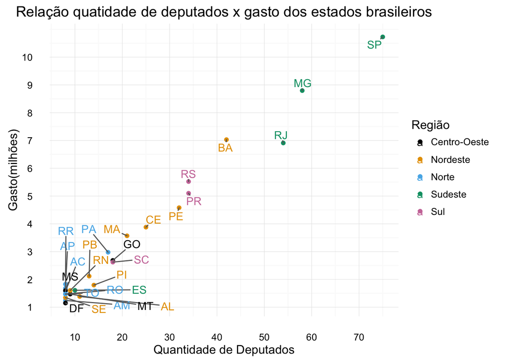

```r
plot(myPlot)
```